# Pre-processing

## PRE-PROCESSING

### **Table of Contents**

1. Introduction
2. Setup
3. Helper Functions
4. Loading data
5. Pre-processing  
   5.1. Using Image Dataset from Directory  
   5.2. Using Image Data Generator
6. Training a model
7. References

### **1. Introduction**

The goal is to learn how to work with images. We will primarily cover how to:

- Load data.
- Perform basic preprocessing.
- Implement data augmentation (a technique that can help improve our results).

### **2. Setup**

```python
import tensorflow as tf
import zipfile
import os
import matplotlib.image as mpimg
import matplotlib.pyplot as plt
from tensorflow.keras import layers
from tensorflow.keras.preprocessing.image import img_to_array, load_img
```

### **3. Helper Functions**

```python
# plot images
def plot_images(train_cat_fnames, train_dog_fnames, nrows=4, ncols=4, n=4):
    """
    Plots a grid of cat and dog images using Matplotlib.

    Args:
        train_cat_fnames (list of str): List of filenames for cat images in the training set.
        train_dog_fnames (list of str): List of filenames for dog images in the training set.
        nrows (int, optional): Number of rows in the plot grid. Defaults to 4.
        ncols (int, optional): Number of columns in the plot grid. Defaults to 4.
        n (int, optional): Number of images to display per class in each call. Defaults to 4.

    Behavior:
        - Initializes a figure with specified rows and columns, adjusting size for display.
        - Selects the next `n` images from each of the cat and dog filename lists.
        - Loads and displays the selected images in a grid layout, with no axis lines or grid.

    Returns:
        None
    """

    pic_index = 0 # Index for iterating over images

    # Set up matplotlib fig, and size it to fit 4x4 pics
    fig = plt.gcf()
    fig.set_size_inches(ncols*4, nrows*4)

    pic_index+=n

    next_cat_pix = [os.path.join(train_cats_dir, fname)
                    for fname in train_cat_fnames[ pic_index-n:pic_index]
                   ]

    next_dog_pix = [os.path.join(train_dogs_dir, fname)
                    for fname in train_dog_fnames[ pic_index-n:pic_index]
                   ]

    for i, img_path in enumerate(next_cat_pix+next_dog_pix):
      # Set up subplot; subplot indices start at 1
      sp = plt.subplot(nrows, ncols, i + 1)
      sp.axis('Off') # Don't show axes (or gridlines)

      img = mpimg.imread(img_path)
      plt.imshow(img)

    plt.show()


# plot augmented images
def plot_augmented_data(data, n, data_augmentation, figsize=(10, 10)):
    """
    Plots augmented images from the dataset.

    Parameters:
    - data: The dataset (e.g., `train_data`).
    - n: The number of augmented images to plot.
    - data_augmentation: A function that applies augmentations to the images.
    - figsize: The size of the plot (default is (10, 10)).
    """
    plt.figure(figsize=figsize)
    for images, _ in data.take(1):
        for i in range(6):
            augmented_images = data_augmentation(images)
            ax = plt.subplot(3, 3, i + 1)
            plt.imshow(augmented_images[0].numpy().astype("uint8"))
            plt.axis("off")


# plot augmented images
def plot_augmented_images_2(img_path, lower_bound=2, upper_bound=10, figsize=(10, 10)):

    """
    Plots the original image along with a series of augmented images generated using a data generator.

    Args:
        img_path (str): Path to the image file that will be augmented.
        lower_bound (int, optional): The starting index for displaying augmented images (default is 2).
        upper_bound (int, optional): The ending index for displaying augmented images (default is 10).
        figsize (tuple, optional): Size of the figure for displaying the images (default is (10, 10)).

    Displays the original image in the first subplot, followed by a sequence of augmented images.
    The augmented images are generated using a data generator (`data_gen`) and are shown in a 3x3 grid.

    Note:
        - The function assumes that a global `data_gen` generator is available for generating augmented images.
        - The image is resized to (256, 256) for consistency before augmentation.
    """

    # Load a single image
    img_path = img_path
    img = load_img(img_path, target_size=(256, 256))  # Resize for consistency
    img_array = img_to_array(img)  # Convert to numpy array
    img_array = np.expand_dims(img_array, axis=0)  # Add batch dimension

    # Create an iterator that generates augmented images
    augmented_images = data_gen.flow(img_array, batch_size=1)

    # Plot the original and augmented images
    plt.figure(figsize=figsize)

    # Display the original image first
    plt.subplot(3, 3, 1)
    plt.imshow(img_array[0] / 255.0)  # Original image (scaled)
    plt.title("Original Image")
    plt.axis('off')

    # Generate and display 8 augmented images
    for i in range(lower_bound, upper_bound):
        batch = next(augmented_images)  # Generate augmented image batch
        augmented_image = batch[0]  # Get the first image from the batch

        plt.subplot(3, 3, i)
        plt.imshow(augmented_image)  # Display the augmented image
        plt.title(f"Augmented {i-1}")
        plt.axis('off')

    plt.tight_layout()
    plt.show()
```

### **4. Loading data**

```python
#!wget --no-check-certificate https://storage.googleapis.com/mledu-datasets/cats_and_dogs_filtered.zip
```

```python
!ls
```

```
cats_and_dogs_filtered.zip  Pre-processing.ipynb
```

```python
# Unzip the archive
local_zip = './cats_and_dogs_filtered.zip'
zip_ref = zipfile.ZipFile(local_zip, 'r')
zip_ref.extractall()

zip_ref.close()
```

```python
!ls
```

```
cats_and_dogs_filtered	cats_and_dogs_filtered.zip  Pre-processing.ipynb
```

```python
!ls cats_and_dogs_filtered
```

```
train  validation  vectorize.py
```

```python
!ls cats_and_dogs_filtered/train
```

```
cats  dogs
```

```python
!ls cats_and_dogs_filtered/train/cats | head -n 5 # show the first 5
```

```
cat.0.jpg
cat.100.jpg
cat.101.jpg
cat.102.jpg
cat.103.jpg
ls: error de escritura: Tubería rota
```

```python
# val
!ls cats_and_dogs_filtered/validation/cats | head -n 5
```

```
cat.2000.jpg
cat.2001.jpg
cat.2002.jpg
cat.2003.jpg
cat.2004.jpg
```

The dataset has the structure shown in the following figure:

[figure not shown]

Now, let's do the same as before but with python:

```python
base_dir = 'cats_and_dogs_filtered'

train_dir = os.path.join(base_dir, 'train')
validation_dir = os.path.join(base_dir, 'validation')

# Directory with training cat/dog pictures
train_cats_dir = os.path.join(train_dir, 'cats')
train_dogs_dir = os.path.join(train_dir, 'dogs')

# Directory with validation cat/dog pictures
validation_cats_dir = os.path.join(validation_dir, 'cats')
validation_dogs_dir = os.path.join(validation_dir, 'dogs')
```

```python
train_cat_fnames = os.listdir(train_cats_dir)
train_dog_fnames = os.listdir(train_dogs_dir)

print(train_cat_fnames[:10])
print()
print(train_dog_fnames[:10])
```

```
['cat.998.jpg', 'cat.731.jpg', 'cat.341.jpg', 'cat.416.jpg', 'cat.342.jpg', 'cat.992.jpg', 'cat.116.jpg', 'cat.905.jpg', 'cat.901.jpg', 'cat.182.jpg']

['dog.334.jpg', 'dog.321.jpg', 'dog.692.jpg', 'dog.549.jpg', 'dog.625.jpg', 'dog.485.jpg', 'dog.413.jpg', 'dog.124.jpg', 'dog.174.jpg', 'dog.245.jpg']
```

```python
print('total training cat images :', len(os.listdir(train_cats_dir)))
print('total training dog images :', len(os.listdir(train_dogs_dir)))

print('total validation cat images :', len(os.listdir(validation_cats_dir)))
print('total validation dog images :', len(os.listdir(validation_dogs_dir)))
```

```
total training cat images : 1000
total training dog images : 1000
total validation cat images : 500
total validation dog images : 500
```

Let's plot a few images:

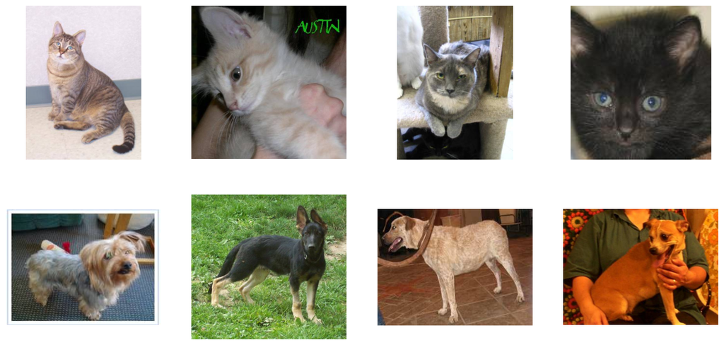

```python
plot_images(train_cat_fnames, train_dog_fnames)
```

It may not be obvious from looking at the images in this grid but an important note here is that these images come in all shapes and sizes. So before training a neural network with them, you'll need to tweak the images.

### **5. Pre-processing**

### **5.1. Using image dataset from directory**

Let's start by using image_dataset_from_directory

tf.keras.preprocessing.image_dataset_from_directory(

```
directory,
labels='inferred',
label_mode='int',
class_names=None,
color_mode='rgb',
batch_size=32,
image_size=(256, 256),
shuffle=True,
seed=None,
validation_split=None,
subset=None,
interpolation='bilinear',
follow_links=False,
crop_to_aspect_ratio=False,
pad_to_aspect_ratio=False,
data_format=None,
verbose=True
```

)

Let's talk a little bit about the most important args:

- image_size
  - Size to resize images to after they are read from disk, specified as (height, width). Defaults to (256, 256). Since the pipeline processes batches of images that must all have the same size, this must be provided.
- validation_split
  - Optional float between 0 and 1, fraction of data to reserve for validation.
- subset
  - Subset of the data to return. One of "training", "validation", or "both". Only used if validation_split is set. When subset="both", the utility returns a tuple of two datasets (the training and validation datasets respectively).
- label_mode
  - String describing the encoding of labels. Options are:
    - "int": means that the labels are encoded as integers (e.g. for sparse_categorical_crossentropy loss).
    - "categorical" means that the labels are encoded as a categorical vector (e.g. for categorical_crossentropy loss).
    - "binary" means that the labels (there can be only 2) are encoded as float32 scalars with values 0 or 1 (e.g. for binary_crossentropy).
    - None (no labels).

```python
data_dir
```

```
'cats_and_dogs_filtered'
```

```python
data_dir = train_dir
img_size=256
batch_size=2 # for better understanding when printing
seed_value = 57

data = tf.keras.preprocessing.image_dataset_from_directory(directory=data_dir,
                                                       shuffle=True,
                                                       seed=seed_value,
                                                       image_size=(img_size,img_size),
                                                       label_mode='categorical',
                                                       batch_size=batch_size)
```

```
Found 2000 files belonging to 2 classes.
```

```python
type(data)
```

```
tensorflow.python.data.ops.prefetch_op._PrefetchDataset
```

```python
for x, y in data.take(1):
    print(f"Shape of x: {x.shape} -> (batch_size, img_size)")
    print(f"Shape of y: {y.shape} -> (batch_size, 2) because label_mode is categorical and we have 2 classes")
    print(x, y)
```

```
Shape of x: (2, 256, 256, 3) -> (batch_size, img_size)
Shape of y: (2, 2) -> (batch_size, 2) because label_mode is categorical and we have 2 classes
tf.Tensor(
[[[[155.        152.        133.       ]
   [155.        152.        133.       ]
   [155.        152.        133.       ]
   ...
   [137.        136.        118.       ]
   [136.82297   135.1589    117.49093  ]
   [136.4668    133.4668    116.4668   ]]

  [[155.        152.        133.       ]
   [155.        152.        133.       ]
   [155.        152.        133.       ]
   ...
   [137.        136.        118.       ]
   [137.33203   135.66797   118.       ]
   [138.        135.        118.       ]]

  [[155.        152.        133.       ]
   [155.        152.        133.       ]
   [155.        152.        133.       ]
   ...
   [137.        136.        118.       ]
   [137.11024   135.44618   117.77821  ]
   [137.33203   134.33203   117.33203  ]]

  ...

  [[139.29312   122.29311    93.625145 ]
   [135.32617   118.32617    89.6582   ]
   [128.69019   111.69018    85.09788  ]
   ...
   [ 59.10547    42.10547    25.286606 ]
   [ 58.454643   41.786674   26.118706 ]
   [ 52.666016   36.666016   21.666016 ]]

  [[134.75586   117.15625    92.35547  ]
   [130.92981   113.33021    88.52943  ]
   [125.370224  107.72526    83.01519  ]
```

[output cut: 50 more lines]

```
   [206.39374   188.79999   178.79999  ]
   ...
   [ 35.1875     23.40625    49.       ]
   [ 34.84375    22.84375    46.53125  ]
   [ 34.         22.         44.       ]]

  [[214.3006    196.3006    186.3006   ]
   [209.48187   191.48187   181.48187  ]
   [209.5763    191.98254   181.98254  ]
   ...
   [ 35.1875     23.40625    49.       ]
   [ 34.84375    22.84375    46.53125  ]
   [ 34.         22.         44.       ]]]], shape=(2, 256, 256, 3), dtype=float32) tf.Tensor(
[[1. 0.]
 [0. 1.]], shape=(2, 2), dtype=float32)
```

We observe the following:

- **Batch size**: 2
- **Image size**: 256 x 256 x 3 (height x width x channels), where `channels=3` indicates color images (RGB).
- **Output `y`**: One-hot encoded with a shape of `(2,)`, representing the two classes.
- The values of the pixles in the images are NOT normalized.

Now, let's change the label mode and see what happens:

```python
data_dir = train_dir
img_size=256
batch_size=1 # for better understanding when printing
seed_value = 57

data = tf.keras.preprocessing.image_dataset_from_directory(directory=data_dir,
                                                       shuffle=True,
                                                       seed=seed_value,
                                                       image_size=(img_size,img_size),
                                                       label_mode='binary',
                                                       batch_size=batch_size)
```

```
Found 2000 files belonging to 2 classes.
```

```python
for _, y in data.take(1):
    print(f"Y.shape: {y.shape}")
    print(y)
```

```
Y.shape: (1, 1)
tf.Tensor([[0.]], shape=(1, 1), dtype=float32)
```

Now, the output is either 0 or 1 depending if its cat or dog.

```python
data.class_names
```

```
['cats', 'dogs']
```

In tf.keras.preprocessing.image_dataset_from_directory, the labels are automatically assigned based on the alphabetical order of the subfolder names within the specified directory. The first folder alphabetically gets the label 0, and the second folder gets the label 1.

In this case:

- Images in the cats folder will have the label 0.
- Images in the dogs folder will have the label 1.

Now let's also generate the validation set (here, I already have it divided, but we can use the given validation set as a test set and generate the validation set from the training set).

```python
data_train, data_val = tf.keras.preprocessing.image_dataset_from_directory(directory=train_dir,
                                                       shuffle=True,
                                                       seed=seed_value,
                                                       image_size=(img_size,img_size),
                                                       label_mode='categorical',
                                                       validation_split=0.2,
                                                       subset='both',
                                                       batch_size=batch_size)
```

```
Found 2000 files belonging to 2 classes.
Using 1600 files for training.
Using 400 files for validation.
```

### Normalization

We need to normalize the data, for that purpose we divide the value of the pixels in the image by 255.

We have 2 options:

- Include the normalization in the model.
- Create and apply a normalization function.

The first option looks like this:

def make_model(input_shape, num_classes):

```
inputs = tf.keras.Input(shape=input_shape)

# normalization
x = layers.Rescaling(1.0 / 255)(inputs)

.....
```

Let's implement the second one in more detail:

```python
# Load dataset
train_ds = tf.keras.preprocessing.image_dataset_from_directory(
    "cats_and_dogs_filtered",
    image_size=(256, 256),  # Target image size
    batch_size=2
)

# Define the rescaling function
def rescale(image, label):
    image = tf.cast(image, tf.float32) / 255.0  # Scale pixel values to [0, 1]
    return image, label

# Apply rescaling before prefetching
train_ds = train_ds.map(rescale)

# Add prefetch for performance optimization
train_ds = train_ds.prefetch(buffer_size=tf.data.AUTOTUNE)
```

```
Found 3000 files belonging to 2 classes.
```

```python
for x, _ in train_ds.take(1):
    print(x)
```

```
tf.Tensor(
[[[[0.32689184 0.35042125 0.43669578]
   [0.31182945 0.33535886 0.42163336]
   [0.33139956 0.35492897 0.44120347]
   ...
   [0.30460566 0.3242135  0.410488  ]
   [0.28786588 0.30747372 0.39374822]
   [0.29986215 0.31947    0.4057445 ]]

  [[0.3788878  0.4037499  0.48935807]
   [0.35736474 0.38222685 0.467835  ]
   [0.3532645  0.37812665 0.4637348 ]
   ...
   [0.3168251  0.33643293 0.42270744]
   [0.3344891  0.35409695 0.44037145]
   [0.35509554 0.37470338 0.46097788]]

  [[0.37570184 0.4070744  0.48942733]
   [0.3331975  0.36457005 0.446923  ]
   [0.30076635 0.3321389  0.41449183]
   ...
   [0.30603024 0.3256381  0.4119126 ]
   [0.34036255 0.3599704  0.4462449 ]
   [0.35987124 0.37947908 0.4657536 ]]

  ...

  [[0.4983182  0.5672971  0.6785878 ]
   [0.50737554 0.5771007  0.68237555]
   [0.53797126 0.60731465 0.71566737]
   ...
   [0.40027016 0.46594113 0.53702724]
   [0.41665134 0.47962624 0.55206037]
   [0.40563402 0.4738785  0.5436778 ]]

  [[0.5467096  0.61364335 0.71629345]
   [0.5476949  0.61681575 0.71419626]
   [0.56097656 0.62897843 0.729055  ]
   ...
   [0.36470103 0.42164037 0.49575713]
```

[output cut: 46 more lines]

```
  [[0.48689395 0.44767827 0.40846258]
   [0.4991211  0.45733187 0.41554266]
   [0.5140654  0.46700653 0.4199477 ]
   ...
   [0.98045343 0.92947304 0.86672795]
   [0.98045343 0.92947304 0.86672795]
   [0.98045343 0.92947304 0.86672795]]

  [[0.46689358 0.4276779  0.38846222]
   [0.48830327 0.44651404 0.40472484]
   [0.5137571  0.46669826 0.41963944]
   ...
   [0.9843137  0.93333334 0.87058824]
   [0.9843137  0.93333334 0.87058824]
   [0.9843137  0.93333334 0.87058824]]]], shape=(2, 256, 256, 3), dtype=float32)
```

We can see that the pixel values are now normalized to the range [0, 1].

### Data Augmentation

Some common techniques are:

- **Rotation**:
  - Rotates the image by a random degree within a specified range. This helps the model become invariant to the orientation of objects in the image.
- **Horizontal and Vertical Flipping**:
  - Flips the image along the horizontal or vertical axis. This simulates different viewing angles and helps the model generalize to various perspectives.
- **Zooming**:
  - Randomly zooms in or out on an image. This enables the model to recognize objects at varying scales and distances.
- **Brightness Adjustment**:
  - Randomly adjusts the brightness of the image. This helps the model perform better under different lighting conditions.
- **Shearing**:
  - Applies a shearing transformation, which distorts the image in a direction. This simulates changes in perspective or viewpoint.
- **Translation**:
  - Shifts the image horizontally or vertically. This makes the model more robust to objects appearing in different parts of the image.
- **Gaussian Noise Addition**:
  - Adds random noise to the image. This helps the model handle noisy or low-quality images more effectively.
- **Color Jitter**:
  - Randomly adjusts the image's hue, saturation, and contrast. This increases robustness to variations in color.

These techniques improve model generalization by simulating real-world variability, reducing overfitting, and making the model more resilient to unseen data.

```python
# Define the transformations
data_augmentation = tf.keras.Sequential(
    [
        layers.RandomFlip("horizontal"),         # Flips the images horizontally
        layers.RandomRotation(0.2),              # Rotates the images within a range of [-0.2, 0.2] radians
        layers.RandomZoom(0.2),                  # Zooms in a range of [0.8, 1.2]
        layers.RandomHeight(0.2),                # Randomly changes the height of the image
        layers.RandomWidth(0.2),                 # Randomly changes the width of the image
        layers.RandomContrast(0.2),              # Adjusts the contrast of the image
        layers.RandomBrightness(0.2),            # Adjusts the brightness of the image
    ]
)


train_data = data_train

# Apply
train_data = train_data.map(
    lambda x, y: (data_augmentation(x, training=True), y))
```

Let's plot:

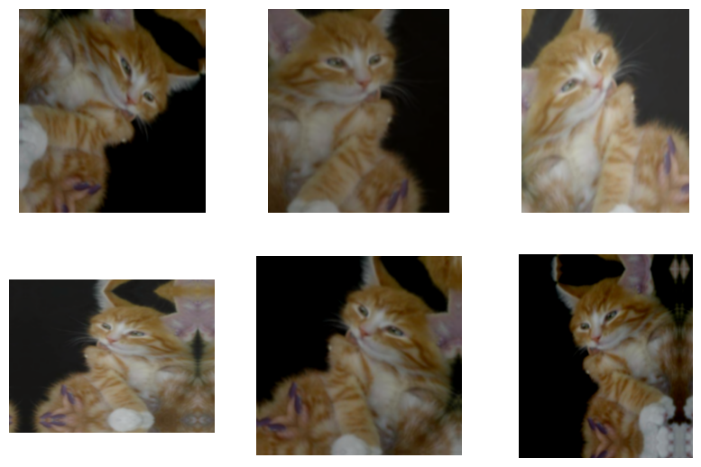

```python
plot_augmented_data(train_data, 6, data_augmentation)
```

### **5.2. Using Image Data Generator**

Let's use [Image Data Generator](https://www.tensorflow.org/api_docs/python/tf/keras/preprocessing/image/ImageDataGenerator)

tf.keras.preprocessing.image.ImageDataGenerator(

```
featurewise_center=False,
samplewise_center=False,
featurewise_std_normalization=False,
samplewise_std_normalization=False,
zca_whitening=False,
zca_epsilon=1e-06,
rotation_range=0,
width_shift_range=0.0,
height_shift_range=0.0,
brightness_range=None,
shear_range=0.0,
zoom_range=0.0,
channel_shift_range=0.0,
fill_mode='nearest',
cval=0.0,
horizontal_flip=False,
vertical_flip=False,
rescale=None,
preprocessing_function=None,
data_format=None,
validation_split=0.0,
interpolation_order=1,
dtype=None
```

)

We can see that already includes posibilities for reescaling and data augmentation.

```python
from tensorflow.keras.preprocessing.image import ImageDataGenerator

# All images will be rescaled by 1./255.
train_datagen = ImageDataGenerator( rescale = 1.0/255. )
test_datagen  = ImageDataGenerator( rescale = 1.0/255. )

type(train_datagen)
```

```
keras.src.preprocessing.image.ImageDataGenerator
```

Now, we are going to use the flow_from_directory method, a generator, which takes in the path to the parent directory containing different classes of image data and generates batches of images. This is the expected directory structure of the flow_from_directory method:

```
main_directory/
...class_a/
......a_image_1.jpg
......a_image_2.jpg
...class_b/
......b_image_1.jpg
......b_image_2.jpg
...class_c/
......c_image_1.jpg
......c_image_2.jpg
```

```python
# Flow training images in batches of 20 using train_datagen generator
train_generator = train_datagen.flow_from_directory(train_dir,
                                                    batch_size=20,
                                                    class_mode='binary',
                                                    target_size=(150, 150))

# Flow validation images in batches of 20 using test_datagen generator
validation_generator =  test_datagen.flow_from_directory(validation_dir,
                                                         batch_size=20,
                                                         class_mode  = 'binary',
                                                         target_size = (150, 150))
```

```
Found 2000 images belonging to 2 classes.
Found 1000 images belonging to 2 classes.
```

```python
type(train_datagen), type(train_generator)
```

```
(keras.src.preprocessing.image.ImageDataGenerator,
 keras.src.preprocessing.image.DirectoryIterator)
```

### Data Augmentation

Now, let's apply data augmentation.

train_datagen = ImageDataGenerator(

```
  rotation_range=40,
  width_shift_range=0.2,
  height_shift_range=0.2,
  shear_range=0.2,
  zoom_range=0.2,
  horizontal_flip=True,
  fill_mode='nearest')
```

These are just a few of the options available. Let's quickly go over it:

- rotation_range
  - is a value in degrees (0–180) within which to randomly rotate pictures.
- width_shift and height_shift
  - are ranges (as a fraction of total width or height) within which to randomly translate pictures vertically or horizontally.
- shear_range
  - is for randomly applying shearing transformations.
- zoom_range
  - is for randomly zooming inside pictures.
- horizontal_flip
  - is for randomly flipping half of the images horizontally. This is relevant when there are no assumptions of horizontal assymmetry (e.g. real-world pictures).
- fill_mode
  - is the strategy used for filling in newly created pixels, which can appear after a rotation or a width/height shift.

```python
train_datagen = ImageDataGenerator(
      rescale=1./255,
      rotation_range=40,
      width_shift_range=0.2,
      height_shift_range=0.2,
      shear_range=0.2,
      zoom_range=0.2,
      horizontal_flip=True,
      fill_mode='nearest')

test_datagen = ImageDataGenerator(rescale=1./255)

# Flow training images in batches of 20 using train_datagen generator
train_generator = train_datagen.flow_from_directory(
        train_dir,  # This is the source directory for training images
        target_size=(256, 256),  # All images will be resized to 150x150
        batch_size=20,
        # Since we use binary_crossentropy loss, we need binary labels
        class_mode='binary')

# Flow validation images in batches of 20 using test_datagen generator
validation_generator = test_datagen.flow_from_directory(
        validation_dir,
        target_size=(256, 256),
        batch_size=20,
        class_mode='binary')
```

```
Found 2000 images belonging to 2 classes.
Found 1000 images belonging to 2 classes.
```

```python
type(train_datagen)
```

```
keras.src.preprocessing.image.ImageDataGenerator
```

```python
for batch_images, batch_labels in train_generator:
    # batch_images: array of image data with shape (batch_size, height, width, channels)
    # batch_labels: array of labels corresponding to the images

    # Process the batch here (e.g., feed into a model or visualize)
    # For example:
    print("Batch of images shape:", batch_images.shape)
    print("Batch of labels shape:", batch_labels.shape)

    # Optional: break the loop after a few batches for testing
    break
```

```
Batch of images shape: (20, 256, 256, 3)
Batch of labels shape: (20,)
```

Let's plot:

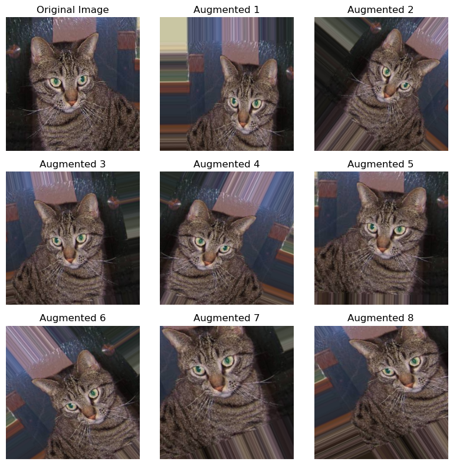

```python
plot_augmented_images_2('cats_and_dogs_filtered/train/cats/cat.1.jpg', figsize=(8,8))
```

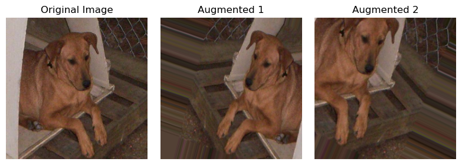

```python
plot_augmented_images_2('cats_and_dogs_filtered/train/dogs/dog.100.jpg', 2, 4, figsize=(8,8))
```

### **6. Training a model**

Finally, let's train a simple model.

```python
model = tf.keras.models.Sequential([
    # Note the input shape is the desired size of the image 256x256 with 3 bytes color
    tf.keras.layers.Conv2D(16, (3,3), activation='relu', input_shape=(256, 256, 3)),
    tf.keras.layers.MaxPooling2D(2,2),
    tf.keras.layers.Conv2D(32, (3,3), activation='relu'),
    tf.keras.layers.MaxPooling2D(2,2),
    # Flatten the results to feed into a DNN
    tf.keras.layers.Flatten(),
    # 512 neuron hidden layer
    tf.keras.layers.Dense(512, activation='relu'),
    # Only 1 output neuron. It will contain a value from 0-1 where 0 for 1 class ('cats') and 1 for the other ('dogs')
    tf.keras.layers.Dense(1, activation='sigmoid')
])


model.compile(loss='binary_crossentropy',
                optimizer='Adam',
                metrics=['accuracy'])
```

```python
history = model.fit(
            train_generator,
            epochs=2,
            validation_data=validation_generator
            )
```

[output not shown]

### **7. References**

[TensorFlow Developer Certificate](https://www.coursera.org/professional-certificates/tensorflow-in-practice)